# Applied Machine Learning Using mlr3

Data and Basic Modelling

Author

Paul Smith

Published

March 3, 2025

## Introduction and prerequisites

The `{mlr3}` package uses the R6 class system alongside `data.table` to store and operate on tabular data.

For a brief introduction to the R6 class system, see [Section 1.5.1](https://mlr3book.mlr-org.com/chapters/chapter1/introduction_and_overview.html#sec-r6) of the mlr3 book, or the package [vignette](https://r6.r-lib.org/articles/Introduction.html).

For information on the `data.table` format, see the package [vignette](https://cran.r-project.org/web/packages/data.table/vignettes/datatable-intro.html). Some brief examples are given below.

```r
library(mlr3)
library(mlr3viz)
library(ggplot2)
library(patchwork)
library(data.table)
options(datatable.print.nrows = 20)
library(palmerpenguins)
```

### Some `data.table` examples

```r
input <- if (file.exists("flights14.csv")) {
   "flights14.csv"
} else {
  "https://raw.githubusercontent.com/Rdatatable/data.table/master/vignettes/flights14.csv"
}
flights <- fread(input)

# by default, DT shows first and last 5 rows
flights
```

```
         year month   day dep_delay arr_delay carrier origin   dest air_time
        <int> <int> <int>     <int>     <int>  <char> <char> <char>    <int>
     1:  2014     1     1        14        13      AA    JFK    LAX      359
     2:  2014     1     1        -3        13      AA    JFK    LAX      363
     3:  2014     1     1         2         9      AA    JFK    LAX      351
     4:  2014     1     1        -8       -26      AA    LGA    PBI      157
     5:  2014     1     1         2         1      AA    JFK    LAX      350
    ---
253312:  2014    10    31         1       -30      UA    LGA    IAH      201
253313:  2014    10    31        -5       -14      UA    EWR    IAH      189
253314:  2014    10    31        -8        16      MQ    LGA    RDU       83
253315:  2014    10    31        -4        15      MQ    LGA    DTW       75
253316:  2014    10    31        -5         1      MQ    LGA    SDF      110
        distance  hour
           <int> <int>
     1:     2475     9
     2:     2475    11
     3:     2475    19
     4:     1035     7
     5:     2475    13
    ---
253312:     1416    14
253313:     1400     8
253314:      431    11
253315:      502    11
253316:      659     8
```

The general form of a data.table is given by:

```
DT[i, j, by]

##   R:                 i                 j        by
## SQL:  where | order by   select | update  group by
```

**Selecting rows**

```r
ans <- flights[origin == "JFK" & month == 6L]
ans
```

```
       year month   day dep_delay arr_delay carrier origin   dest air_time
      <int> <int> <int>     <int>     <int>  <char> <char> <char>    <int>
   1:  2014     6     1        -9        -5      AA    JFK    LAX      324
   2:  2014     6     1       -10       -13      AA    JFK    LAX      329
   3:  2014     6     1        18        -1      AA    JFK    LAX      326
   4:  2014     6     1        -6       -16      AA    JFK    LAX      320
   5:  2014     6     1        -4       -45      AA    JFK    LAX      326
  ---
8418:  2014     6    30        -3        -6      MQ    JFK    PIT       62
8419:  2014     6    30        -5       -32      MQ    JFK    RDU       65
8420:  2014     6    30        -3       -16      MQ    JFK    DCA       39
8421:  2014     6    30        -2         7      MQ    JFK    DCA       52
8422:  2014     6    30        -7       -18      MQ    JFK    RDU       67
      distance  hour
         <int> <int>
   1:     2475     8
   2:     2475    12
   3:     2475     7
   4:     2475    10
   5:     2475    18
  ---
8418:      340    14
8419:      427    14
8420:      213    17
8421:      213     7
8422:      427     8
```

**Selecting columns**

```r
# to output a vector
res <- flights[, arr_delay]
head(res)
```

```
[1]  13  13   9 -26   1   0
```

```r
# to output a DT
flights[, .(arr_delay)] # .() is equivalent to list()
```

```
        arr_delay
            <int>
     1:        13
     2:        13
     3:         9
     4:       -26
     5:         1
    ---
253312:       -30
253313:       -14
253314:        16
253315:        15
253316:         1
```

```r
# output multiple columns and rename
flights[, .(delay_arrival = arr_delay, destination = dest)]
```

```
        delay_arrival destination
                <int>      <char>
     1:            13         LAX
     2:            13         LAX
     3:             9         LAX
     4:           -26         PBI
     5:             1         LAX
    ---
253312:           -30         IAH
253313:           -14         IAH
253314:            16         RDU
253315:            15         DTW
253316:             1         SDF
```

```r
# selecting using names in j, similar to data.frame
flights[, c("arr_delay", "dest")]
```

```
        arr_delay   dest
            <int> <char>
     1:        13    LAX
     2:        13    LAX
     3:         9    LAX
     4:       -26    PBI
     5:         1    LAX
    ---
253312:       -30    IAH
253313:       -14    IAH
253314:        16    RDU
253315:        15    DTW
253316:         1    SDF
```

```r
# or, if stored in a character vector, use `..`
# similar to "up-one-level" Unix terminal command
which_cols <- c("arr_delay", "dest")
flights[, ..which_cols]
```

```
        arr_delay   dest
            <int> <char>
     1:        13    LAX
     2:        13    LAX
     3:         9    LAX
     4:       -26    PBI
     5:         1    LAX
    ---
253312:       -30    IAH
253313:       -14    IAH
253314:        16    RDU
253315:        15    DTW
253316:         1    SDF
```

**Computing in j**

```r
# how many trips had total delay of < 0?
flights[, sum((arr_delay + dep_delay) < 0)]
```

```
[1] 141814
```

```r
# average arrival and departure delay for all flights in June with origin "JFK"
flights[month == 6 & origin == "JFK",
       .(m_arr = mean(arr_delay), m_dep = mean(dep_delay))]
```

```
      m_arr    m_dep
      <num>    <num>
1: 5.839349 9.807884
```

#### Aggregations

** Grouping using `by`**

```r
# Number of trips corresponding to each origin airport
flights[, .(.N), by = .(origin)]
```

```
   origin     N
   <char> <int>
1:    JFK 81483
2:    LGA 84433
3:    EWR 87400
```

```r
# can drop .() if only one expression in j
flights[carrier == "AA", .N, by = origin]
```

```
   origin     N
   <char> <int>
1:    JFK 11923
2:    LGA 11730
3:    EWR  2649
```

```r
# total number of trips for each origin, dest pair for carrier code "AA"
flights[carrier == "AA", .N, by = .(origin, dest)]
```

```
    origin   dest     N
    <char> <char> <int>
 1:    JFK    LAX  3387
 2:    LGA    PBI   245
 3:    EWR    LAX    62
 4:    JFK    MIA  1876
 5:    JFK    SEA   298
---
20:    JFK    EGE    85
21:    JFK    DFW   474
22:    JFK    SAN   299
23:    JFK    DCA   172
24:    EWR    PHX   121
```

```r
# average arrival and departure delay for each origin, dest pair for each month for carrier code "AA"
flights[carrier == "AA",
       .(m_arr = mean(arr_delay), m_dep = mean(dep_delay)),
       by = .(origin, dest, month)]
```

```
     origin   dest month      m_arr      m_dep
     <char> <char> <int>      <num>      <num>
  1:    JFK    LAX     1   6.590361 14.2289157
  2:    LGA    PBI     1  -7.758621  0.3103448
  3:    EWR    LAX     1   1.366667  7.5000000
  4:    JFK    MIA     1  15.720670 18.7430168
  5:    JFK    SEA     1  14.357143 30.7500000
 ---
196:    LGA    MIA    10  -6.251799 -1.4208633
197:    JFK    MIA    10  -1.880184  6.6774194
198:    EWR    PHX    10  -3.032258 -4.2903226
199:    JFK    MCO    10 -10.048387 -1.6129032
200:    JFK    DCA    10  16.483871 15.5161290
```

**Sorted by `keyby`**

```r
# directly ordering by all the grouping variables
# 'keyby' automatically orders the result by the grouping variables in increasing order
flights[carrier == "AA",
       .(m_arr = mean(arr_delay), m_dep = mean(dep_delay)),
       keyby = .(origin, dest, month)]
```

```
Key: <origin, dest, month>
     origin   dest month      m_arr      m_dep
     <char> <char> <int>      <num>      <num>
  1:    EWR    DFW     1   6.427673 10.0125786
  2:    EWR    DFW     2  10.536765 11.3455882
  3:    EWR    DFW     3  12.865031  8.0797546
  4:    EWR    DFW     4  17.792683 12.9207317
  5:    EWR    DFW     5  18.487805 18.6829268
 ---
196:    LGA    PBI     1  -7.758621  0.3103448
197:    LGA    PBI     2  -7.865385  2.4038462
198:    LGA    PBI     3  -5.754098  3.0327869
199:    LGA    PBI     4 -13.966667 -4.7333333
200:    LGA    PBI     5 -10.357143 -6.8571429
```

**Chaining**\ Looking at getting the total number of trips for each `origin, dest` pair for carrier `AA`.

```r
ans <- flights[carrier == "AA", .N, by = .(origin, dest)]
```

Ordering the columns `origin` in ascending order, and `dest` in descending order:

```r
ans[order(origin, -dest)]
```

```
    origin   dest     N
    <char> <char> <int>
 1:    EWR    PHX   121
 2:    EWR    MIA   848
 3:    EWR    LAX    62
 4:    EWR    DFW  1618
 5:    JFK    STT   229
---
20:    JFK    AUS   297
21:    LGA    PBI   245
22:    LGA    ORD  4366
23:    LGA    MIA  3334
24:    LGA    DFW  3785
```

But, we can do this all in one go using *chaining*. We can tack expressions one after another, forming a chain of operations, i.e., `DT[ ... ][ ... ][ ... ]`.

```r
flights[carrier == "AA", .N, by = .(origin, dest)
        ][order(origin, -dest)]
```

```
    origin   dest     N
    <char> <char> <int>
 1:    EWR    PHX   121
 2:    EWR    MIA   848
 3:    EWR    LAX    62
 4:    EWR    DFW  1618
 5:    JFK    STT   229
---
20:    JFK    AUS   297
21:    LGA    PBI   245
22:    LGA    ORD  4366
23:    LGA    MIA  3334
24:    LGA    DFW  3785
```

#### Expressions in `by`

We can have *expressions* in the `by` index as well as columns. For example, if we would like to find out how many flights started late but arrived early (or on time), started and arrived late.

```r
flights[, .N, .(dep_delay > 0, arr_delay <= 0)]
```

```
   dep_delay arr_delay      N
      <lgcl>    <lgcl>  <int>
1:      TRUE     FALSE  72836
2:     FALSE     FALSE  34583
3:     FALSE      TRUE 119304
4:      TRUE      TRUE  26593
```

#### Multiple columns in j

What if we want to find the mean for lots of columns? We don’t want to have to type `mean(col)` for each column individually. Here, due to the behaviour of DT[^1], we can use the base function `lapply()`.

<sup>1</sup> [Tip:](https://cran.r-project.org/web/packages/data.table/vignettes/datatable-intro.html#tip-1) As long as the j-expression returns a list, each element of the list will be converted to a column in the resulting data.table.

**Special symbol .SD** In `data.table`, we can create a **S**ubset of **D**ata using `.SD`. It is by itself a `data.table` that holds the data for the *current group* defined using `by`.

```r
DT = data.table(
  ID = c("b","b","b","a","a","c"),
  a = 1:6,
  b = 7:12,
  c = 13:18
)
DT
```

```
       ID     a     b     c
   <char> <int> <int> <int>
1:      b     1     7    13
2:      b     2     8    14
3:      b     3     9    15
4:      a     4    10    16
5:      a     5    11    17
6:      c     6    12    18
```

```r
DT[, print(.SD), by = ID]
```

```
       a     b     c
   <int> <int> <int>
1:     1     7    13
2:     2     8    14
3:     3     9    15
       a     b     c
   <int> <int> <int>
1:     4    10    16
2:     5    11    17
       a     b     c
   <int> <int> <int>
1:     6    12    18
Empty data.table (0 rows and 1 cols): ID
```

- `.SD` contains all the columns except the grouping columns by default.
- It is also generated by preserving the original order - data corresponding to ID = “b”, then ID = “a”, and then ID = “c”.

To compute on multiple columns, we can use `lapply()`.

```r
DT[, lapply(.SD, mean), by = ID]
```

```
       ID     a     b     c
   <char> <num> <num> <num>
1:      b   2.0   8.0  14.0
2:      a   4.5  10.5  16.5
3:      c   6.0  12.0  18.0
```

- `.SD` holds the rows corresponding to columns a, b and c for that group. We compute the `mean()` on each of these columns using the already-familiar base function `lapply()`.
- Each group returns a list of three elements containing the mean value which will become the columns of the resulting data.table.
- Since `lapply()` returns a list, so there is no need to wrap it with an additional `.()`

Can you `.SDcols` to specify just the columns we would like to compute the `mean()` on.

```r
flights[carrier == "AA",                       ## Only on trips with carrier "AA"
        lapply(.SD, mean),                     ## compute the mean
        by = .(origin, dest, month),           ## for every 'origin,dest,month'
        .SDcols = c("arr_delay", "dep_delay")] ## for just those specified in .SDcols
```

```
     origin   dest month  arr_delay  dep_delay
     <char> <char> <int>      <num>      <num>
  1:    JFK    LAX     1   6.590361 14.2289157
  2:    LGA    PBI     1  -7.758621  0.3103448
  3:    EWR    LAX     1   1.366667  7.5000000
  4:    JFK    MIA     1  15.720670 18.7430168
  5:    JFK    SEA     1  14.357143 30.7500000
 ---
196:    LGA    MIA    10  -6.251799 -1.4208633
197:    JFK    MIA    10  -1.880184  6.6774194
198:    EWR    PHX    10  -3.032258 -4.2903226
199:    JFK    MCO    10 -10.048387 -1.6129032
200:    JFK    DCA    10  16.483871 15.5161290
```

Subset `.SD` for each group: for example, just returning the first two rows for each month.

```r
flights[, head(.SD, 2), by = month]
```

```
    month  year   day dep_delay arr_delay carrier origin   dest air_time
    <int> <int> <int>     <int>     <int>  <char> <char> <char>    <int>
 1:     1  2014     1        14        13      AA    JFK    LAX      359
 2:     1  2014     1        -3        13      AA    JFK    LAX      363
 3:     2  2014     1        -1         1      AA    JFK    LAX      358
 4:     2  2014     1        -5         3      AA    JFK    LAX      358
 5:     3  2014     1       -11        36      AA    JFK    LAX      375
 6:     3  2014     1        -3        14      AA    JFK    LAX      368
 7:     4  2014     1        -8       -23      MQ    LGA    BNA      113
 8:     4  2014     1        -8       -11      MQ    LGA    RDU       71
 9:     5  2014     1        43         5      AA    JFK    LAS      288
10:     5  2014     1        -1       -38      AA    JFK    SFO      330
11:     6  2014     1        -9        -5      AA    JFK    LAX      324
12:     6  2014     1       -10       -13      AA    JFK    LAX      329
13:     7  2014     1        -3        -2      VX    JFK    SFO      343
```

[output cut: 31 more lines]

Concatenate columns a and b for each group in ID.

Recall that `DT` is

```
       ID     a     b     c
   <char> <int> <int> <int>
1:      b     1     7    13
2:      b     2     8    14
3:      b     3     9    15
4:      a     4    10    16
5:      a     5    11    17
6:      c     6    12    18
```

```r
DT[, .(val = c(a,b)), by = ID]
```

```
        ID   val
    <char> <int>
 1:      b     1
 2:      b     2
 3:      b     3
 4:      b     7
 5:      b     8
 6:      b     9
 7:      a     4
 8:      a     5
 9:      a    10
10:      a    11
11:      c     6
12:      c    12
```

Or, returning as a list column.

```r
DT[, .(val = list(c(a,b))), by = ID]
```

```
       ID         val
   <char>      <list>
1:      b 1,2,3,7,8,9
2:      a  4, 5,10,11
3:      c        6,12
```

**Note**

Once you start internalising usage in j, you will realise how powerful the syntax can be. A very useful way to understand it is by playing around, with the help of print(). Look at the difference between:

```r
##
DT[, print(c(a,b)), by = ID]
```

```
[1] 1 2 3 7 8 9
[1]  4  5 10 11
[1]  6 12
```

```
Empty data.table (0 rows and 1 cols): ID
```

and,

```r
DT[, print(list(c(a,b))), by = ID]
```

```
[[1]]
[1] 1 2 3 7 8 9

[[1]]
[1]  4  5 10 11

[[1]]
[1]  6 12
```

```
Empty data.table (0 rows and 1 cols): ID
```

## Data and basic modelling

**Machine Learning**

the process of learning models of relationships from data

machine learning

**Supervised Learning**

a subfield of ML in which datasets consist of labelled observations. Each data point consists of features (variables to make predictions from), and a target (the quantity we are trying to predict).

supervised learning

**Regression**

the prediction of numeric target values

regression

**Classification**

the prediction of categorical values or labels

classification

**Tasks**

In {mlr3}, the datasets and their associated metadata are referred to as **tasks**.

A ‘task’ refers to the prediction problem that we are trying to solve. They are defined by the features used for prediction and the targets to predict. Therefore, there can be multiple tasks associated with a dataset.

For example, predicting mpg from horsepower is one task; predicting horsepower from mpg is another task; predicting the number of gears from the car’s model is another task; *etc.*

### The aim

The aim of a supervised learning task is to build a model that captures the relationship between the features and the target, such that prediction can be made on new and previously unseen data.

A model is a mapping from a features vector to a prediction, $f: X \rightarrow Y$,
$$f(x) = \hat y.$$

Machine learning algorithms are called **learners** in {mlr3} as, given data, they learn models. Examples of learners include decision trees, support vector machines, and neural networks.

learners

In general, the model is trained on the training data and then the separate test data is used to evaluate models in an unbiased way, by assessing to what extent the model has learned the true relationships that underlie the data. This evaluation procedure estimates a model’s generalization error, i.e., how well we expect the model to perform in general.

This brief overview of ML provides the basic knowledge required to use {mlr3} and is summarized in Figure 1.

[figure not shown]

Figure 1: Overview of ML

## Tasks

From here-in, we will be looking at the penguins dataset from {palmerpenguins} (Horst, Hill, and Gorman 2020). We will first consider a regression task, and then a classification task afterwards.

Horst, Allison Marie, Alison Presmanes Hill, and Kristen B Gorman. 2020. *Palmerpenguins: Palmer Archipelago (Antarctica) Penguin Data*. https://doi.org/10.5281/zenodo.3960218.

### Constructing tasks

There are some premade tasks in {mlr3}’s Dictionary:

```r
mlr_tasks
```

```
<DictionaryTask> with 11 stored values
Keys: breast_cancer, california_housing, german_credit, iris, mtcars,
  penguins, pima, sonar, spam, wine, zoo
```

We can retrieve a task using `tsk()`.

```r
tsk_mtcars = tsk("mtcars")
tsk_mtcars
```

```
<TaskRegr:mtcars> (32 x 11): Motor Trends
* Target: mpg
* Properties: -
* Features (10):
  - dbl (10): am, carb, cyl, disp, drat, gear, hp, qsec, vs, wt
```

**The help page**

In the R6 class, we can get to the help page in multiple ways:

```r
# option 1
?mlr_tasks_mtcars
# option 2
tsk("mtcars")$help()
```

To construct a task using the penguins dataset, we need to construct a new instance of `TaskRegr`. Use the function `as_task_regr()` to convert a `data.frame` (or `tibble`) type object to a regression task.

Using the {palmerpenguins} dataset, we will subset the data to only include columns `species`, `bill_length_mm`, and `body_mass_g`. We will set up a regression task called `pengs` in which we try and predict the body mass (in grams) from the species and the bill length (in mm).

```r
data("penguins", package = "palmerpenguins")

penguins_dt <- as.data.table(penguins)
penguins_dtsub <- penguins_dt[, .(species, bill_length_mm, body_mass_g)]
penguins_dtsub <- na.omit(penguins_dtsub)
tsk_penguins <- as_task_regr(penguins_dtsub, target = "body_mass_g", id = "pengs")
tsk_penguins
```

**1**

Removing `NA`s for simplicity here.

```
<TaskRegr:pengs> (342 x 3)
* Target: body_mass_g
* Properties: -
* Features (2):
  - dbl (1): bill_length_mm
  - fct (1): species
```

Playing around with `data.table`.

```r
# how many of each species
penguins_dtsub[, .N, by = .(species)]
```

```
     species     N
      <fctr> <int>
1:    Adelie   151
2:    Gentoo   123
3: Chinstrap    68
```

```r
# average bill length and body mass for each species
penguins_dtsub[,
               lapply(.SD, mean, na.rm = TRUE),
               by = .(species)]
```

```
     species bill_length_mm body_mass_g
      <fctr>          <num>       <num>
1:    Adelie       38.79139    3700.662
2:    Gentoo       47.50488    5076.016
3: Chinstrap       48.83382    3733.088
```

Lang, Michel, Patrick Schratz, Raphael Sonabend, Marc Becker, Jakob Richter, and John Zobolas. 2025. *Mlr3viz: Visualizations for ’Mlr3’*. https://github.com/mlr-org/mlr3viz.

We can plot the task using the {mlr3viz} package (Lang et al. 2025).

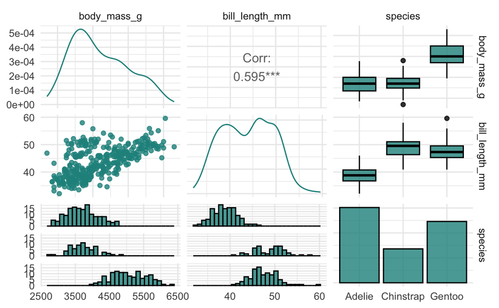

```r
autoplot(tsk_penguins, type = "pairs")
```

### Retrieving data

The dimensions of the task can be retrieved using `$nrow` and `$ncol`:

```r
c(tsk_penguins$nrow, tsk_penguins$ncol)
```

```
[1] 342   3
```

The name of the feature and target columns can be retrieved:

```r
c(Features = tsk_penguins$feature_names,
  Target = tsk_penguins$target_names)
```

```
       Features1        Features2           Target
"bill_length_mm"        "species"    "body_mass_g"
```

The rows of the task are identified by row IDs (which do not necessarily correspond to row numbers).

```r
head(tsk_penguins$row_ids)
```

```
[1] 1 2 3 4 5 6
```

Note that row IDs are not the same as row numbers. This is best demonstrated by example, below we create a regression task from random data, print the original row IDs, which correspond to row numbers 1-5, then we filter three rows (we will return to this method just below) and print the new row IDs, which no longer correspond to the row numbers.

```r
task = as_task_regr(data.frame(x = runif(5),
                               y = runif(5)),
                    target = "y")
task$row_ids
```

```
[1] 1 2 3 4 5
```

```r
task$filter(c(4, 1, 3))
task$row_ids
```

```
[1] 1 3 4
```

The data contained in a task can be accessed through `$data`.

```r
# retrieve all the data
tsk_penguins$data()
```

```
     body_mass_g bill_length_mm   species
           <int>          <num>    <fctr>
  1:        3750           39.1    Adelie
  2:        3800           39.5    Adelie
  3:        3250           40.3    Adelie
  4:        3450           36.7    Adelie
  5:        3650           39.3    Adelie
 ---
338:        4000           55.8 Chinstrap
339:        3400           43.5 Chinstrap
340:        3775           49.6 Chinstrap
341:        4100           50.8 Chinstrap
342:        3775           50.2 Chinstrap
```

```r
# retrieve data for rows with IDs 1, 5, and 10 and all feature columns
tsk_penguins$data(rows = c(1, 5, 10), cols = tsk_penguins$feature_names)
```

```
   bill_length_mm species
            <num>  <fctr>
1:           39.1  Adelie
2:           39.3  Adelie
3:           37.8  Adelie
```

**Accessing rows by number**

You can work with row numbers instead of row IDs by using the `$row_ids` field to extract the row ID corresponding to a given row number.

```r
# select the 2nd row of the task by extracting the second row_id:
tsk_penguins$data(rows = tsk_penguins$row_ids[2])
```

```
   body_mass_g bill_length_mm species
         <int>          <num>  <fctr>
1:        3800           39.5  Adelie
```

Standard R methods can be used to extract summary data from a task, for example,

```r
summary(tsk_penguins)
```

```
  body_mass_g   bill_length_mm       species
 Min.   :2700   Min.   :32.10   Adelie   :151
 1st Qu.:3550   1st Qu.:39.23   Chinstrap: 68
 Median :4050   Median :44.45   Gentoo   :123
 Mean   :4202   Mean   :43.92
 3rd Qu.:4750   3rd Qu.:48.50
 Max.   :6300   Max.   :59.60
```

### Task mutators

Although we can access the data through `$data()`, if we want to modify it (for example, to create a train and test set), we need *mutator*. These modify the `Task` in place.

- `$select()`: subset by features (column)
- `$filter()`: subset by observations (rows)
- `$cbind()`: add extra columns
- `$rbind()`: add extra rows

```r
tsk_penguins_small = tsk_penguins$clone()
tsk_penguins_small$select("species") # keep only one feature
tsk_penguins_small$filter(2:3) # keep only these rows
tsk_penguins_small$data()
```

**1**

As R6 uses [reference semantics](https://mlr3book.mlr-org.com/chapters/chapter1/introduction_and_overview.html#sec-r6), we need to use `$clone()` to ensure the original `Task` remains intact.

```
   body_mass_g species
         <int>  <fctr>
1:        3800  Adelie
2:        3250  Adelie
```

```r
tsk_penguins_small$cbind( # add an extra column
         data.table(funny = c("yes", "no"))
        )
tsk_penguins_small$data()
```

```
   body_mass_g species  funny
         <int>  <fctr> <char>
1:        3800  Adelie    yes
2:        3250  Adelie     no
```

## Learners

In `mlr3`, a **Learner** represents a machine learning model or algorithm that can be trained and used to make predictions. It encapsulates everything needed to fit a model, make predictions, and evaluate performance, offering a consistent interface for different types of models. As with tasks, learners can be accessed from the dictionary with a single sugar function, `lrn()`.

**Key Points:**

- **Learner objects** are used to train and predict. They represent the type of model you want to use (e.g., decision trees, SVM, random forests).
- Example: `lrn("classif.rpart")` creates a classification model using a decision tree. The `rpart` stands for *Recursive Partitioning and Regression Trees*.
- Learners can be created using the `lrn()` function, with the argument specifying the model type (classification, regression, etc.) and the algorithm.
- Common methods for Learners include:
  - `train()` – trains the model on the provided data.
  - `predict()` – makes predictions on new data.
  - `score()` – evaluates the model’s performance using various metrics.

```r
lrn("regr.rpart")
```

```
<LearnerRegrRpart:regr.rpart>: Regression Tree
* Model: -
* Parameters: xval=0
* Packages: mlr3, rpart
* Predict Types:  [response]
* Feature Types: logical, integer, numeric, factor, ordered
* Properties: importance, missings, selected_features, weights
```

All `Learner` objects include the following metadata, which can be seen in the output in the margin:

- `$feature_types`: the type of features the learner can handle.
- `$packages`: the packages required to be installed to use the learner.
- `$properties`: the properties of the learner. For example, the “missings” properties means a model can handle missing data, and “importance” means it can compute the relative importance of each feature.
- `$predict_types`: the types of prediction that the model can make.
- `$param_set`: the set of available hyperparameters.

The two stages that a learner passes through are shown in Figure 2.

[figure not shown]

Figure 2: To run a machine learning experiment, learners pass through two stages, `$train()` and `$predict()`.  
Top – data (features and a target) are passed to an (untrained) learner.  
Bottom – new data are passed to the trained model which makes predictions for the ‘missing’ target column.

### Training

Models are trained by passing a task to a learner with the `$train()` method.

```r
# load a regression tree
lrn_rpart = lrn("regr.rpart")
# pass the task to the learner via $train()
lrn_rpart$train(tsk_penguins)
```

**1**

The help file can be accessed as normal, `lrn_rpart$help()`.

We can examine the model using `$model()`.

```r
# inspect the trained model
lrn_rpart$model
```

```
n= 342

node), split, n, deviance, yval
      * denotes terminal node

1) root 342 219307700 4201.754
  2) species=Adelie,Chinstrap 219  41488530 3710.731
    4) bill_length_mm< 39.05 82  10467870 3480.793 *
    5) bill_length_mm>=39.05 137  24090260 3848.358 *
  3) species=Gentoo 123  31004250 5076.016
    6) bill_length_mm< 47.75 69   9126377 4782.246 *
    7) bill_length_mm>=47.75 54   8314271 5451.389 *
```

We see that the regression tree has identified features in the task that are predictive of the target (`body_mass_g`) and used them to partition observations.

#### Partitioning Data

We can partition the data into a training and a test set (default size $2/3$ and $1/3$, respectively) using the `partition()` function.

```r
splits = partition(tsk_penguins)
splits
```

```
$train
  [1]   1   3   4   5   7   8   9  12  13  14  18  21  24  25  26  29  31  32
 [19]  35  37  38  40  41  42  43  44  46  47  49  50  52  54  55  56  57  60
 [37]  61  63  64  65  68  69  70  71  72  73  75  76  77  79  80  82  83  84
 [55]  86  87  89  90  92  94  95  96  97  98 100 101 103 106 108 110 111 112
 [73] 114 115 117 118 119 121 122 123 124 125 127 130 132 134 136 138 139 140
 [91] 142 143 144 145 146 148 149 151 152 153 154 155 156 159 164 166 167 168
[109] 169 170 172 173 174 175 179 180 181 182 189 190 191 192 193 194 195 196
[127] 197 199 200 201 202 204 205 208 210 211 212 215 217 218 220 221 222 223
[145] 225 226 227 228 230 231 232 233 234 235 236 239 241 243 245 248 249 250
[163] 251 254 255 256 257 258 259 260 261 263 264 265 266 267 269 270 271 272
[181] 274 275 276 277 278 279 281 283 284 285 286 287 288 290 291 292 293 294
[199] 295 297 298 299 300 301 304 305 309 313 314 316 317 318 319 320 321 322
[217] 323 324 325 326 330 332 333 335 336 338 339 340 341

$test
  [1]   2   6  10  11  15  16  17  19  20  22  23  27  28  30  33  34  36  39
 [19]  45  48  51  53  58  59  62  66  67  74  78  81  85  88  91  93  99 102
 [37] 104 105 107 109 113 116 120 126 128 129 131 133 135 137 141 147 150 157
 [55] 158 160 161 162 163 165 171 176 177 178 183 184 185 186 187 188 198 203
 [73] 206 207 209 213 214 216 219 224 229 237 238 240 242 244 246 247 252 253
 [91] 262 268 273 280 282 289 296 302 303 306 307 308 310 311 312 315 327 328
[109] 329 331 334 337 342

$validation
integer(0)
```

When training we will tell the model to only use the training data by passing the row IDs from `partition` to the `row_ids` argument of `$train()`:

```r
lrn_rpart$train(tsk_penguins, row_ids = splits$train)
```

Now we can use our trained learner to make predictions on new data.

#### Predicting

To predict, we pass the data as a `Task` to the `$predict()` method of the trained `Learner`.

```r
prediction = lrn_rpart$predict(tsk_penguins, row_ids = splits$test)
prediction
```

**1**

You can also use `$predict_newdata()` to pass a `data.frame` directly.

```
<PredictionRegr> for 113 observations:
 row_ids truth response
       2  3800 3793.396
       6  3625 3793.396
      10  3300 3793.396
     ---   ---      ---
     334  3525 3793.396
     337  3650 3793.396
     342  3775 3793.396
```

We can plot `Prediction` objects using `{mlr3viz}`, shown in Figure 3.

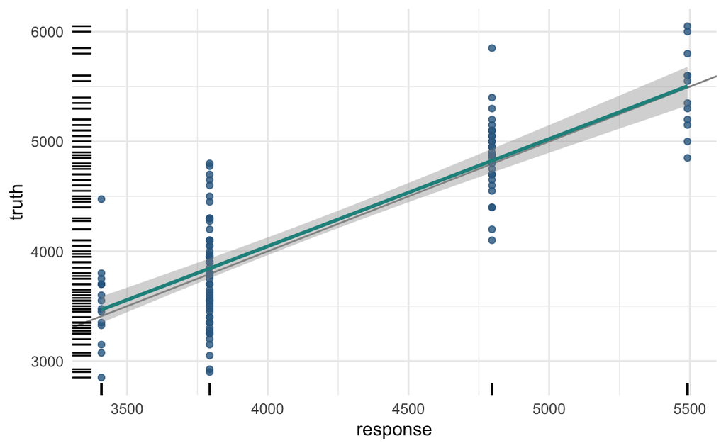

Figure 3: Comparing predicted and ground truth values for the penguins dataset

```r
autoplot(prediction)
```

### Hyperparameters

Hyperparameters are parameters of a machine learning model that are not learned from the data during training, but are set before the training process begins. They affect how the algorithm is run and can be set by the user.

Hyperparameters Key Points:

- Model Settings: Hyperparameters determine how a model learns and the type of model used.
  - Example for Decision Trees: Maximum tree depth or minimum number of samples per leaf.
  - Example for SVM: Regularization parameter (`C`) and the kernel type.
  - Example for Neural Networks: Learning rate, number of hidden layers, number of neurons per layer.
- Not Learned: Hyperparameters are manually set before training and remain fixed during training, unlike parameters which are learned from the data.
- Importance: Hyperparameters have a significant impact on model performance. The right choice can improve accuracy, while poor choices can lead to underfitting or overfitting.

The hyperparameters can be accessed using `$param_set`.

```r
lrn_rpart$param_set
```

**1**

The output here is a `ParamSet` object, supplied by the [`paradox` package](https://paradox.mlr-org.com/)

```
<ParamSet(10)>
                id    class lower upper nlevels        default  value
            <char>   <char> <num> <num>   <num>         <list> <list>
 1:             cp ParamDbl     0     1     Inf           0.01 [NULL]
 2:     keep_model ParamLgl    NA    NA       2          FALSE [NULL]
 3:     maxcompete ParamInt     0   Inf     Inf              4 [NULL]
 4:       maxdepth ParamInt     1    30      30             30 [NULL]
 5:   maxsurrogate ParamInt     0   Inf     Inf              5 [NULL]
 6:      minbucket ParamInt     1   Inf     Inf <NoDefault[0]> [NULL]
 7:       minsplit ParamInt     1   Inf     Inf             20 [NULL]
 8: surrogatestyle ParamInt     0     1       2              0 [NULL]
 9:   usesurrogate ParamInt     0     2       3              2 [NULL]
10:           xval ParamInt     0   Inf     Inf             10      0
```

| Hyperparameter Class | Hyperparameter Type |
| --- | --- |
| `ParamDbl` | Real-valued (numeric) |
| `ParamInt` | Integer |
| `ParamFct` | Categorical (factor) |
| `ParamLgl` | Logical / Boolean |
| `ParamUty` | Untyped |

The hyperparameters can be changed when constructing the `Learner`.

```r
lrn_rpart = lrn("regr.rpart", maxdepth = 1)

# obtain a list of the non-default hyperparameters
lrn_rpart$param_set$values
```

**1**

You can also change the default hyperparameters using `lrn_rpart$param_set$set_values(xval = 2, cp = 0.5)`.

**2**

The `xval` hyperparameter is initialized to 0 because `xval` controls internal cross-validations and if a user accidentally leaves this at the default 10, model training can take an unnecessarily long time.

```
$maxdepth
[1] 1

$xval
[1] 0
```

We can see the `maxdepth` effect by looking at the learned regression tree.

```r
lrn_rpart$train(tsk_penguins)$model
```

```
n= 342

node), split, n, deviance, yval
      * denotes terminal node

1) root 342 219307700 4201.754
  2) species=Adelie,Chinstrap 219  41488530 3710.731 *
  3) species=Gentoo 123  31004250 5076.016 *
```

#### Baseline Learners

Baseline learners are very simple (‘weak’) learners, that can be used as baselines to test new models against. For example, `lrn("regr.featureless")`, will always predict new values to be the mean (or median, if the `robust` hyperparameter is set to `TRUE`) of the target in the training data.

```r
# generate data
df = as_task_regr(data.frame(x = runif(1000), y = rnorm(1000, 2, 1)),
  target = "y")
lrn("regr.featureless")$train(df, 1:995)$predict(df, 996:1000)
```

```
<PredictionRegr> for 5 observations:
 row_ids    truth response
     996 2.852987 2.014346
     997 1.275122 2.014346
     998 1.818804 2.014346
     999 2.454076 2.014346
    1000 1.532576 2.014346
```

## Evaluation

Evaluating model performance is *probably a good idea*. Lets do this on our penguins decision tree example. Recall we have created a `Task`, and the data was split before being passed through a `Learner`.

```r
# this code is for reference (it is not being run again).
tsk_penguins <- as_task_regr(penguins_dtsub, target = "body_mass_g", id = "pengs")
splits = partition(tsk_penguins)
lrn_rpart$train(tsk_penguins, splits$train)
prediction = lrn_rpart$predict(tsk_penguins, splits$test)
```

### Measures

Models are evaluated using measures. The available measures are stored in the `mlr_measures` dictionary, which we can access using `msr()`.

```r
as.data.table(msr())
```

```
Key: <key>
             key                          label task_type          packages
          <char>                         <char>    <char>            <list>
 1:          aic   Akaike Information Criterion      <NA>              mlr3
 2:          bic Bayesian Information Criterion      <NA>              mlr3
 3:  classif.acc        Classification Accuracy   classif mlr3,mlr3measures
 4:  classif.auc       Area Under the ROC Curve   classif mlr3,mlr3measures
 5: classif.bacc              Balanced Accuracy   classif mlr3,mlr3measures
---
61:  sim.jaccard       Jaccard Similarity Index      <NA> mlr3,mlr3measures
62:      sim.phi     Phi Coefficient Similarity      <NA> mlr3,mlr3measures
63:    time_both                   Elapsed Time      <NA>              mlr3
64: time_predict                   Elapsed Time      <NA>              mlr3
65:   time_train                   Elapsed Time      <NA>              mlr3
    predict_type
          <char>
 1:         <NA>
 2:         <NA>
 3:     response
 4:         prob
 5:     response
---
61:         <NA>
62:         <NA>
63:         <NA>
64:         <NA>
65:         <NA>
                                                         properties
                                                             <list>
 1: na_score,requires_learner,requires_model,requires_no_prediction
 2: na_score,requires_learner,requires_model,requires_no_prediction
 3:
 4:
 5:
---
61:                                                  requires_model
62:                                                  requires_model
63:                         requires_learner,requires_no_prediction
64:                         requires_learner,requires_no_prediction
65:                         requires_learner,requires_no_prediction
    task_properties
             <list>
 1:
 2:
 3:
 4:        twoclass
 5:
---
61:
62:
63:
64:
65:
```

Lets consider the mean absolute error (MAE) `Measure`, which compares the absolute difference between the predicted and actual error,
$$f(y, \hat y) = |y - \hat y|.$$

```r
measure = msr("regr.mae")
measure
```

```
<MeasureRegrSimple:regr.mae>: Mean Absolute Error
* Packages: mlr3, mlr3measures
* Range: [0, Inf]
* Minimize: TRUE
* Average: macro
* Parameters: list()
* Properties: -
* Predict type: response
```

This output is telling us the following:

- Measure: Mean Absolute Error (MAE) for regression tasks.
- Packages: mlr3, mlr3measures.
- Range: $[0, \infty]$ (lower is better).
- Minimize: True (aim to minimize the error).
- Average: Macro average (averaged across all data points).
- Parameters: There are no additional parameters.
- Properties: There are no special properties associated with this measure
- Predict type: Response (compares predicted values to actual values).

### Scoring predictions

We use a measure to score our predictions and evaluate the model. To do this we call the `$score()` method of a `Prediction` object and pass as a single argument the measure that we want to compute:

```r
prediction$score(measure)
```

**1**

Note that all task types have default measures that are used if the argument to `$score()` is omitted

```
regr.mae
334.1386
```

Multiple measures can be calculated at the same time:

```r
# mean squared error and mean absolute error
measures = msrs(c("regr.mse", "regr.mae"))
prediction$score(measures)
```

**1**

Note that the function is `msrs`, not `msr`, when there is more than one measure.

```
   regr.mse    regr.mae
175887.7719    334.1386
```

**Obtaining meta-information using measures**

Some measures do not quantify the quality of the model, but instead give us some information. For example:

- `msr("time_train")` – The time taken to train a model.
- `msr("time_predict")` – The time taken for the model to make predictions.
- `msr("time_both")` – The total time taken to train the model and then make predictions.
- `msr("selected_features")` – The number of features selected by a model, which can only be used if the model has the “selected_features” property.

```r
measures = msrs(c("time_train", "time_predict", "time_both"))
prediction$score(measures, learner = lrn_rpart)
```

**1**

We had to pass `learner = lrn_rpart` to `$score()` as these measures have the `requires_learner` property, which can be seen from `msr("time_train")$properties`.

```
  time_train time_predict    time_both
       0.001        0.000        0.001
```

## Let’s Regress!

I will put everything together now and assess the quality of the predictions. I’ll do this by comparing the performance of a featureless regression learner to a decision tree with changed hyperparameters. I looked at the list of available hyperparameters in Section 0.4.2

Listing 1: Regressing on {palmerpenguins}

```r
set.seed(349)
# load and partition our task
tsk_penguins <- as_task_regr(penguins_dtsub, target = "body_mass_g", id = "pengs")
splits = partition(tsk_penguins)
# load featureless learner
lrn_featureless = lrn("regr.featureless")
# load decision tree and set hyperparameters
lrn_rpart = lrn("regr.rpart", cp = 0.2, maxdepth = 5)
# load MSE and MAE measures
measures = msrs(c("regr.mse", "regr.mae"))
# train learners
lrn_featureless$train(tsk_penguins, splits$train)
lrn_rpart$train(tsk_penguins, splits$train)
# make and score predictions
lrn_featureless$predict(tsk_penguins,
                        splits$test)$score(measures)
```

```
   regr.mse    regr.mae
698241.7303    706.2507
```

```r
lrn_rpart$predict(tsk_penguins, splits$test)$score(measures)
```

```
   regr.mse    regr.mae
202875.2852    354.5231
```

For both MSE and MAE, lower values are ‘better’ (`Minimize: TRUE`) and therefore I am concluding (for now) that the decision tree performs better than the featureless baseline. Later, I’ll look at formalising this conclusion using benchmarking.

# Classification

## A classification experiment

The code below is very similar to that given in Listing 1, except that the tasks, learners and measures inherit from [`TaskClassif`](https://mlr3.mlr-org.com/reference/TaskClassif.html), [`LearnerClassif`](https://mlr3.mlr-org.com/reference/LearnerClassif.html), and [`MeasureClassif`](https://mlr3.mlr-org.com/reference/MeasureClassif.html), respectively.

```r
set.seed(349)
# load and partition our task
tsk_penguins = tsk("penguins")
splits = partition(tsk_penguins)
# load featureless learner
lrn_featureless = lrn("classif.featureless")
# load decision tree and set hyperparameters
lrn_rpart = lrn("classif.rpart", cp = 0.2, maxdepth = 5)
# load accuracy measure
measure = msr("classif.acc")
# train learners
lrn_featureless$train(tsk_penguins, splits$train)
lrn_rpart$train(tsk_penguins, splits$train)
# make and score predictions
lrn_featureless$predict(tsk_penguins, splits$test)$score(measure)
lrn_rpart$predict(tsk_penguins, splits$test)$score(measure)
```

**1**

By default, the featureless learner always predicts the most common class in the training data.

**2**

The measure calculates the number of correct predictions divided by total number of predictions

```
classif.acc
  0.4561404
classif.acc
  0.9473684
```

So, classification and regression is very similar in {mlr3}. Let’s look at the differences.

### TaskClassif

I can create a classifier task using `as_task_classif`,

```r
tsk_penguins <- as_task_classif(palmerpenguins::penguins, target = "species")
tsk_penguins
```

```
<TaskClassif:palmerpenguins::penguins> (344 x 8)
* Target: species
* Properties: multiclass
* Features (7):
  - int (3): body_mass_g, flipper_length_mm, year
  - dbl (2): bill_depth_mm, bill_length_mm
  - fct (2): island, sex
```

As the target in the penguins dataset has three outcomes, this is multiclass classification (as seen in the `Properties` row above. If the outcome has only two options, then it would be binary classification.

```r
tsk_penguins$class_names
```

```
[1] "Adelie"    "Chinstrap" "Gentoo"
```

The task can be plotted using [autoplot.TaskClassif](https://mlr3viz.mlr-org.com/reference/autoplot.TaskClassif.html).

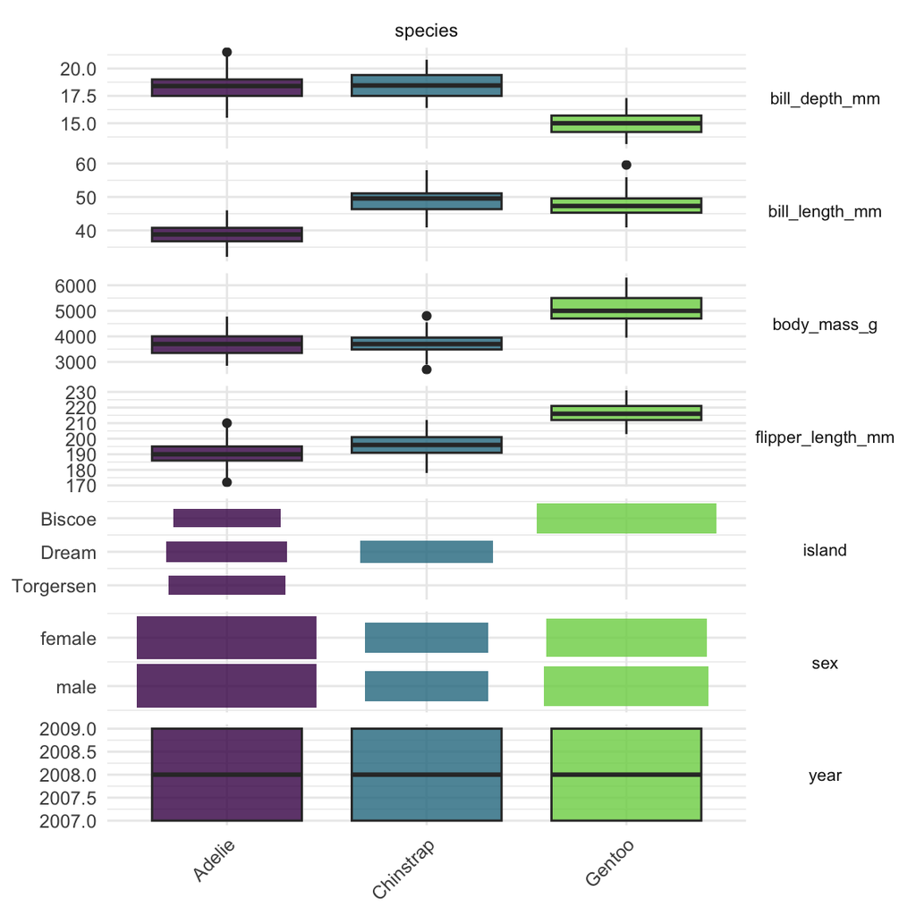

```r
autoplot(tsk_penguins, type = "duo") +
  theme(strip.text.y = element_text(angle = -0, size = 8))
```

### LearnerClassif and MeasureClassif

Classification learners can either predict the outcome class, or the probability of belonging to each class.

```r
# to obtain class predictions
#lrn_rpart = lrn("classif.rpart", predict_type = "response")
# to obtain probability predictions
lrn_rpart = lrn("classif.rpart", predict_type = "prob")
lrn_rpart$train(tsk_penguins, splits$train)
prediction = lrn_rpart$predict(tsk_penguins, splits$test)
prediction
```

```
<PredictionClassif> for 114 observations:
 row_ids     truth  response prob.Adelie prob.Chinstrap prob.Gentoo
       1    Adelie    Adelie  0.97029703     0.02970297   0.0000000
       2    Adelie    Adelie  0.97029703     0.02970297   0.0000000
       3    Adelie    Adelie  0.97029703     0.02970297   0.0000000
     ---       ---       ---         ---            ---         ---
     338 Chinstrap Chinstrap  0.04255319     0.93617021   0.0212766
     339 Chinstrap Chinstrap  0.04255319     0.93617021   0.0212766
     342 Chinstrap Chinstrap  0.04255319     0.93617021   0.0212766
```

The `response` in the output above is by default the class with the highest predicted probability.

The measures available are difference for `response` predictions (require `predict_type = "response"`) and `prob` predictions (require `predict_type = "prob"`). A list of measures for the `multiclass` task, and the probability learners can be seen below.

```r
as.data.table(msr())[
    task_type == "classif" & predict_type == "prob" &
    !sapply(task_properties, function(x) "twoclass" %in% x)]
```

**1**

Removing the measures for binary classification.

```
Key: <key>
                 key                                      label task_type
              <char>                                     <char>    <char>
1:   classif.logloss                                   Log Loss   classif
2: classif.mauc_au1p    Weighted average 1 vs. 1 multiclass AUC   classif
3: classif.mauc_au1u             Average 1 vs. 1 multiclass AUC   classif
4: classif.mauc_aunp Weighted average 1 vs. rest multiclass AUC   classif
5: classif.mauc_aunu          Average 1 vs. rest multiclass AUC   classif
6:   classif.mauc_mu                          Multiclass mu AUC   classif
7:    classif.mbrier                     Multiclass Brier Score   classif
            packages predict_type properties task_properties
              <list>       <char>     <list>          <list>
1: mlr3,mlr3measures         prob
2: mlr3,mlr3measures         prob
3: mlr3,mlr3measures         prob
4: mlr3,mlr3measures         prob
5: mlr3,mlr3measures         prob
6: mlr3,mlr3measures         prob
7: mlr3,mlr3measures         prob
```

We can evaluate the quality of our probability predictions and response predictions simultaneously by providing multiple measures. Let’s consider the [Brier score](https://en.wikipedia.org/wiki/Brier_score) (between [0, 1], where 0 is best), the log-loss (negative logarithm of the predicted probability for the true class), and the accuracy (number of correct predictions divided by total number of predictions).

### PredictionClassif

[`PredictionClassif`](https://mlr3.mlr-org.com/reference/PredictionClassif.html) objects have two important differences to the regression versions – the added field `$confusion`, and the added method `$set_threshold()`.

```r
measures = msrs(c("classif.mbrier", "classif.logloss", "classif.acc"))
prediction$score(measures)
```

```
 classif.mbrier classif.logloss     classif.acc
      0.1028996       0.7548078       0.9385965
```

We can obtain the confusion matrix from the prediction obtain.

```r
prediction$confusion
```

```
           truth
response    Adelie Chinstrap Gentoo
  Adelie        48         2      0
  Chinstrap      4        14      1
  Gentoo         0         0     45
```

All off-diagonal entries are incorrectly classified observations, and all diagonal entries are correctly classified.

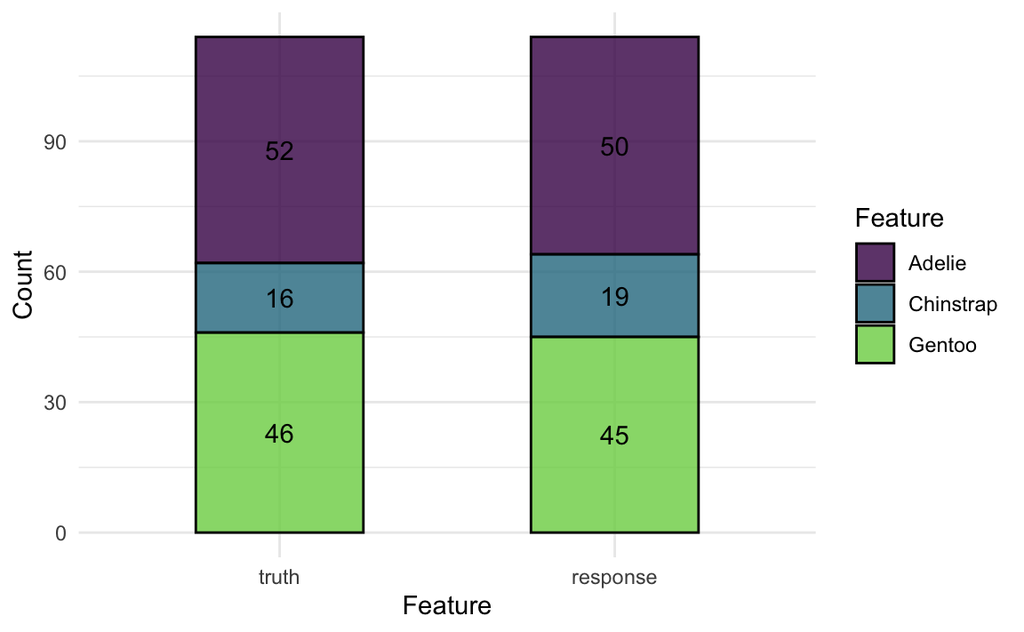

```r
autoplot(prediction)
```

For changing the threshold of the predicted probabily to select a class, see the [{mlr3} Threshold section](https://mlr3book.mlr-org.com/chapters/chapter2/data_and_basic_modeling.html#thresholding). One quick example shows the use of inverse veighting to obtain a model that more accurately captures the underlying relationship between classes.

In multiclass classification, thresholding works by first assigning a threshold to each of the n classes, dividing the predicted probabilities for each class by these thresholds to return n ratios, and then the class with the highest ratio is selected.

```r
tsk_zoo = tsk("zoo")
tsk_zoo
```

```
<TaskClassif:zoo> (101 x 17): Zoo Animals
* Target: type
* Properties: multiclass
* Features (16):
  - lgl (15): airborne, aquatic, backbone, breathes, catsize, domestic,
    eggs, feathers, fins, hair, milk, predator, tail, toothed, venomous
  - int (1): legs
```

```r
splits = partition(tsk_zoo)
lrn_rpart = lrn("classif.rpart", predict_type = "prob")
lrn_rpart$train(tsk_zoo, splits$train)
prediction = lrn_rpart$predict(tsk_zoo, splits$test)
before = autoplot(prediction) + ggtitle("Default thresholds")
new_thresh = proportions(table(tsk_zoo$truth(splits$train)))
new_thresh
```

```
       mammal          bird       reptile          fish     amphibian
   0.42647059    0.16176471    0.05882353    0.17647059    0.04411765
       insect mollusc.et.al
   0.07352941    0.05882353
```

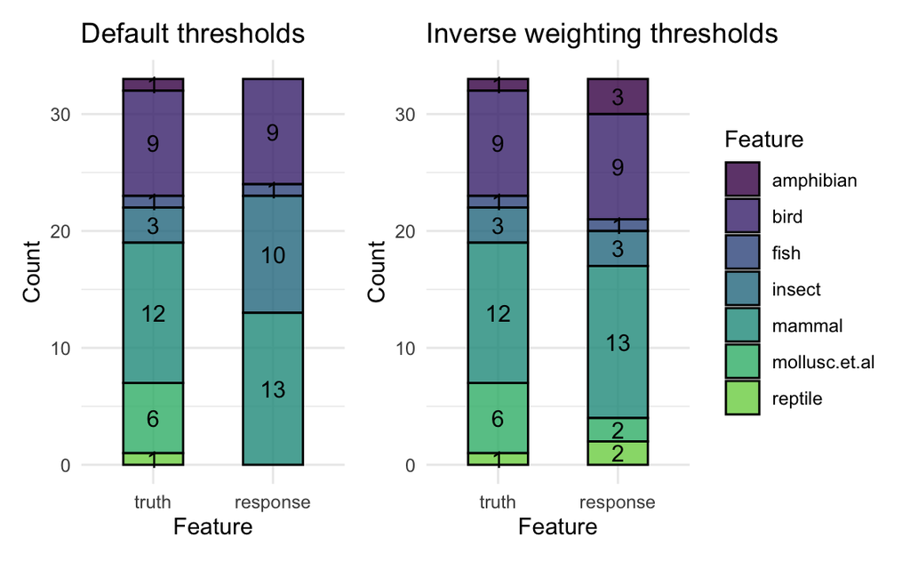

```r
prediction$set_threshold(new_thresh)
after = autoplot(prediction) + ggtitle("Inverse weighting thresholds")
before + after + plot_layout(guides = "collect")
```

# Learning algorithms

The `mlr3learners` package contains a selection of algorithms (and select implementations) chosen by the `mlr` team that we recommend as a good starting point for most experiments:

- Linear (`"regr.lm"`) and logistic (`"classif.log_reg"`) regression.
- Penalized generalized linear models, where the penalization is either exposed as a hyperparameter (`"regr.glmnet"`/`"classif.glmnet"`) or where it is optimized automatically (`"regr.cv_glmnet"`/`"classif.cv_glmnet"`).
- Weighted -Nearest Neighbors (`"regr.kknn"`/`"classif.kknn"`).
- Kriging / Gaussian process regression (`"regr.km"`).
- Linear (`"classif.lda"`) and quadratic (`"classif.qda"`) discriminant analysis.
- Naïve Bayes classification (`"classif.naive_bayes"`).
- Support-vector machines (`"regr.svm"`/`"classif.svm"`).
- Gradient boosting (`"regr.xgboost"`/`"classif.xgboost"`).
- Random forests for regression and classification (`"regr.ranger"`/`"classif.ranger"`).

# Conclusion

| Class | Constructor/Function | Fields/Methods |
| --- | --- | --- |
| Task | `tsk()`/`tsks()`/`as_task_X` | `$filter(); $select(); $data()` |
| Learner | `lrn()`/`lrns()` | `$train(); $predict(); $predict_newdata(); $model()` |
| Prediction | `some_learner$predict()` | `$score(); $set_threshold(); $confusion` |
| Measure | `msr()`/`msrs()` | `-` |

# Exercises

### Question 1

Train a classification model with the `"classif.rpart"` learner on the Pima Indians Diabetes dataset. Do this without using `tsk("pima")`, and instead by constructing a task from the dataset in the `mlbench` package: `data(PimaIndiansDiabetes2, package = "mlbench")`.

**Missing data**

Note: The dataset has `NA`s in its features. You can either rely on `rpart`’s capability to handle them internally (surrogate splits) or remove them from the initial `data.frame` using `na.omit()`.

The rpart algorithm has a built-in method called surrogate splits, which allows it to handle missing values without removing data. If a feature value is missing at a particular split, rpart:

1. Tries to use an alternative feature (a surrogate variable) that closely mimics the main splitting feature.
2. If no good surrogate is found, it assigns the most common class (for classification) or the mean value (for regression) within that split.
- Make sure to define the `pos` outcome as the positive class.
- Train the model on a random 80% subset of the given data and evaluate its performance with the classification error measure on the remaining data.

#### Answer

Loading the data:

```r
data(PimaIndiansDiabetes2, package = "mlbench")
pima <- as.data.table(PimaIndiansDiabetes2)
pima
```

```
     pregnant glucose pressure triceps insulin  mass pedigree   age diabetes
        <num>   <num>    <num>   <num>   <num> <num>    <num> <num>   <fctr>
  1:        6     148       72      35      NA  33.6    0.627    50      pos
  2:        1      85       66      29      NA  26.6    0.351    31      neg
  3:        8     183       64      NA      NA  23.3    0.672    32      pos
  4:        1      89       66      23      94  28.1    0.167    21      neg
  5:        0     137       40      35     168  43.1    2.288    33      pos
 ---
764:       10     101       76      48     180  32.9    0.171    63      neg
765:        2     122       70      27      NA  36.8    0.340    27      neg
766:        5     121       72      23     112  26.2    0.245    30      neg
767:        1     126       60      NA      NA  30.1    0.349    47      pos
768:        1      93       70      31      NA  30.4    0.315    23      neg
```

I want to predict whether each person has diabetes, using a CART (‘classification and regression tree’).

##### Creating a task

First, I create the `task`. I am defining `pos` to be the positive class in this step. It can also be done later by setting `tsk_pima$positive = "pos"`.

```r
tsk_pima <- as_task_classif(pima, target = "diabetes", positive = "pos")
tsk_pima
```

```
<TaskClassif:pima> (768 x 9)
* Target: diabetes
* Properties: twoclass
* Features (8):
  - dbl (8): age, glucose, insulin, mass, pedigree, pregnant, pressure,
    triceps
```

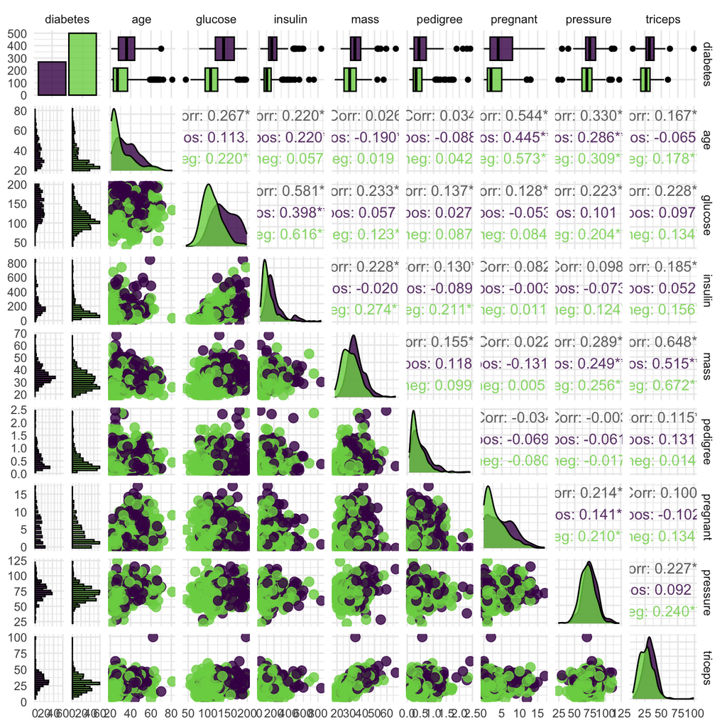

Figure 4: A pairs plot of the `pima` dataset. Note that it is unbalanced, as there are more negative diabetes outcomes than positive.

```r
#autoplot(tsk_pima, type = "duo") +
  #theme(strip.text.y = element_text(angle = -0, size = 8))

autoplot(tsk_pima, type = "pairs")
```

Let’s see how unbalanced the data is…

```r
pima[, .N, by = "diabetes"]
```

```
   diabetes     N
     <fctr> <int>
1:      pos   268
2:      neg   500
```

##### Splitting the data

Create a split of $80\%$ training and $20\%$ test data.

**Important**

I know this is bad practice. Most of the time (see below for caveats), all the data should be used to fit the model, and then internal validation done via resampling (*e.g.* using bootstrap or cross-validation).

From Frank Harrell’s [blog](https://www.fharrell.com/post/split-val/),

> data splitting is an unstable method for validating models or classifiers, especially when the number of subjects is less than about 20,000 (fewer if signal:noise ratio is high). This is because were you to split the data again, develop a new model on the training sample, and test it on the holdout sample, the results are likely to vary significantly. Data splitting requires a significantly larger sample size than resampling to work acceptably well

Also see Steyerberg (2018).

To chose whether to do internal or external validation, see the Biostatistics for Biomedical Research [summary](https://hbiostat.org/bbr/reg.html#summary-choosing-internal-vs.-external-validation).

Steyerberg, Ewout W. 2018. “Validation in Prediction Research: The Waste by Data Splitting.” *Journal of Clinical Epidemiology* 103: 131–33.

```r
set.seed(52)
splits <- partition(tsk_pima, ratio = 0.8)
splits
```

```
$train
  [1]   1   2   3   4   5   8   9  10  11  12  14  18  19  20  21  22  23  24
 [19]  25  27  28  29  30  31  32  34  35  36  37  38  39  40  41  42  43  44
 [37]  46  48  49  50  51  52  53  54  55  56  57  58  59  60  61  62  63  64
 [55]  65  66  69  70  71  72  77  78  79  80  81  82  83  85  86  88  89  90
 [73]  91  92  93  94  97  98  99 100 101 103 104 105 106 107 108 109 110 111
 [91] 112 113 114 116 117 118 119 120 121 122 123 124 125 128 129 130 132 133
[109] 135 136 137 138 139 140 142 143 144 145 146 148 149 151 152 153 157 158
[127] 159 160 161 162 163 164 165 166 167 169 170 171 173 174 175 177 178 179
[145] 180 181 182 183 184 185 186 187 188 189 190 191 194 195 196 197 198 199
[163] 200 201 202 203 204 205 206 207 209 210 212 213 215 216 217 218 220 221
[181] 222 224 225 226 228 229 231 233 234 235 236 237 238 243 244 245 246 247
[199] 248 251 252 255 256 257 258 259 261 262 263 264 266 267 268 269 270 271
[217] 273 275 276 277 279 280 281 282 283 284 285 286 287 290 291 292 293 294
[235] 295 297 298 299 301 302 305 306 307 309 310 311 312 313 314 315 316 318
```

[output cut: 35 more lines]

##### Training the model

Now, I will train the classification tree on the training data.

```r
# loading the learners
lrn_featureless <- lrn("classif.featureless", predict_type = "prob")
lrn_rpart <- lrn("classif.rpart", predict_type = "prob") # 'prob' is the default prediction type
lrn_rpart
```

```
<LearnerClassifRpart:classif.rpart>: Classification Tree
* Model: -
* Parameters: xval=0
* Packages: mlr3, rpart
* Predict Types:  response, [prob]
* Feature Types: logical, integer, numeric, factor, ordered
* Properties: importance, missings, multiclass, selected_features,
  twoclass, weights
```

```r
# training the learners
lrn_featureless$train(tsk_pima, splits$train)
lrn_rpart$train(tsk_pima, splits$train)
```

##### Evaluating the model

Here, I’m evaluating the model on the test data (and comparing against the featureless learner).

I will consider the Brier, log-loss and accuracy `measures`. The [Brier score](https://en.wikipedia.org/wiki/Brier_score) lies between [0, 1], where 0 is best. The log-loss is the negative logarithm of the predicted probability for the true class, and the accuracy is the number of correct predictions divided by total number of predictions.

```r
# load accuracy measures
measures = msrs(c("classif.mbrier", "classif.logloss", "classif.acc"))

# predicting using the featureless learner
prediction_featureless <- lrn_featureless$predict(tsk_pima, splits$test)
prediction_featureless
```

```
<PredictionClassif> for 154 observations:
 row_ids truth response  prob.pos  prob.neg
       6   neg      neg 0.3485342 0.6514658
       7   pos      neg 0.3485342 0.6514658
      13   neg      neg 0.3485342 0.6514658
     ---   ---      ---       ---       ---
     747   pos      neg 0.3485342 0.6514658
     755   pos      neg 0.3485342 0.6514658
     768   neg      neg 0.3485342 0.6514658
```

```r
# obtaining score of featureless learner
prediction_featureless$score(measures)
```

```
 classif.mbrier classif.logloss     classif.acc
      0.4553977       0.6478575       0.6493506
```

```r
# predicting using the classification tree
prediction_rpart <- lrn_rpart$predict(tsk_pima, splits$test)
prediction_rpart
```

```
<PredictionClassif> for 154 observations:
 row_ids truth response   prob.pos  prob.neg
       6   neg      neg 0.00000000 1.0000000
       7   pos      neg 0.08675799 0.9132420
      13   neg      neg 0.24390244 0.7560976
     ---   ---      ---        ---       ---
     747   pos      pos 0.77777778 0.2222222
     755   pos      pos 0.76744186 0.2325581
     768   neg      neg 0.08675799 0.9132420
```

```r
# obtaining score of the classification tree
prediction_rpart$score(measures)
```

```
 classif.mbrier classif.logloss     classif.acc
      0.2763229       0.8516860       0.8246753
```

```r
# confusion matrix
prediction_rpart$confusion
```

**1**

All off-diagonal entries are incorrectly classified observations, and all diagonal entries are correctly classified.

```
        truth
response pos neg
     pos  40  13
     neg  14  87
```

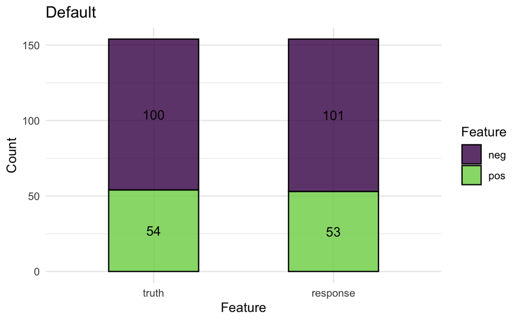

```r
prediction_plot <- autoplot(prediction_rpart) + ggtitle("Default")
prediction_plot
```

### Question 2

Calculate the true positive, false positive, true negative, and false negative rates of the predictions made by the model in Exercise 1.

- Try to solve this in two ways:
  1. Using `mlr3measures`-predefined measure objects.
  2. Without using `mlr3` tools by directly working on the ground truth and prediction vectors.
- Compare the results.

#### Answer

I’ve already started this in Question 1 (Section 4.0.1.1.4), but I will reiterate here. The confusion matrix gives the number of predictions that are correct (true positives or negatives) on the diagonal, and those that are incorrect (false positives and negatives) on the top right and bottom left, respectively

```r
# confusion matrix
conf_matrix <- prediction_rpart$confusion
conf_matrix
```

```
        truth
response pos neg
     pos  40  13
     neg  14  87
```

I want to obtain the *rates*, both using the [`mlr3measures`](https://mlr3.mlr-org.com/reference/mlr_measures.html) objects, and without.

**Sensitivity**

(true positive rate) is the probability of a positive test result, conditioned on the individual truly being positive.

**Specificity**

(true negative rate) is the probability of a negative test result, conditioned on the individual truly being negative.

##### Using `mlr3measures`

First, let’s figure out the measures we need…

```r
as.data.table(mlr_measures)[task_type == "classif" & predict_type == "response"]
```

```
Key: <key>
                    key                         label task_type
                 <char>                        <char>    <char>
 1:         classif.acc       Classification Accuracy   classif
 2:        classif.bacc             Balanced Accuracy   classif
 3:          classif.ce          Classification Error   classif
 4:       classif.costs Cost-sensitive Classification   classif
 5:         classif.dor         Diagnostic Odds Ratio   classif
---
19: classif.specificity                   Specificity   classif
20:          classif.tn                True Negatives   classif
21:         classif.tnr            True Negative Rate   classif
22:          classif.tp                True Positives   classif
23:         classif.tpr            True Positive Rate   classif
             packages predict_type properties task_properties
               <list>       <char>     <list>          <list>
 1: mlr3,mlr3measures     response
 2: mlr3,mlr3measures     response
 3: mlr3,mlr3measures     response
 4:              mlr3     response
 5: mlr3,mlr3measures     response                   twoclass
---
19: mlr3,mlr3measures     response                   twoclass
20: mlr3,mlr3measures     response                   twoclass
21: mlr3,mlr3measures     response                   twoclass
22: mlr3,mlr3measures     response                   twoclass
23: mlr3,mlr3measures     response                   twoclass
```

OK, so we need to use the measures `classif.tpr` `classif.fpr` `classif.tnr` and `classif.fnr`, for the true positive, false positive, true negative and false negative rates, respectively.

```r
measures <- msrs(c("classif.tpr", "classif.fpr", "classif.tnr", "classif.fnr"))
prediction_rpart$score(measures)
```

```
classif.tpr classif.fpr classif.tnr classif.fnr
  0.7407407   0.1300000   0.8700000   0.2592593
```

##### Without using `mlr3measures`

I can obtain these rates directly from the confusion matrix.

```r
str(conf_matrix)
```

```
 'table' int [1:2, 1:2] 40 14 13 87
 - attr(*, "dimnames")=List of 2
  ..$ response: chr [1:2] "pos" "neg"
  ..$ truth   : chr [1:2] "pos" "neg"
```

```r
# true positive rate / sensitivity
tpr <- conf_matrix[1, 1]/ sum(conf_matrix[, 1])
# false positive rate
fpr <- conf_matrix[1, 2]/ sum(conf_matrix[, 2])

# true negative rate / specificity
tnr <- conf_matrix[2, 2]/ sum(conf_matrix[, 2])
# false negative rate
fnr <- conf_matrix[2, 1]/ sum(conf_matrix[, 1])

data.table(
  classif.tpr = tpr,
  classif.fpr = fpr,
  classif.tnr = tnr,
  classif.fnr = fnr
)
```

```
   classif.tpr classif.fpr classif.tnr classif.fnr
         <num>       <num>       <num>       <num>
1:   0.7407407        0.13        0.87   0.2592593
```

### Question 3

Change the threshold of the model from Question 1 such that the false positive rate is lower than the false negative rate.

- What is one reason you might do this in practice?

#### Answer

One reason I might want a lower false positive rate than false negative rate is it the damage done by a false positive is higher than that done by a false negative. That if, if classifying the outcome as positive when it is actually negative is more damaging than the other way round. For example, if I am building a model to predict fraud for a bank, and a false positive would result in a customer transaction being wrongly declined. Lots of false positives could result in annoyed customers and a loss of trust.

##### Inverse weights

Let’s first change the thresholds such that they account for the inbalanced data. I’m not considering false positives here.

From Figure 4, it’s clear that the data is unbalanced (more people with negative diabetes than positive). I can account for this by changing the thresholds using inverse weightings.

First, let’s use the training data to obtain new thresholds.

```r
new_thresh = proportions(table(tsk_pima$truth(splits$train)))
new_thresh
```

```
      pos       neg
0.3485342 0.6514658
```

And then I’ll use these thresholds to reweight the model.

```r
prediction_rpart$set_threshold(new_thresh)
prediction_rpart$confusion
```

```
        truth
response pos neg
     pos  40  13
     neg  14  87
```

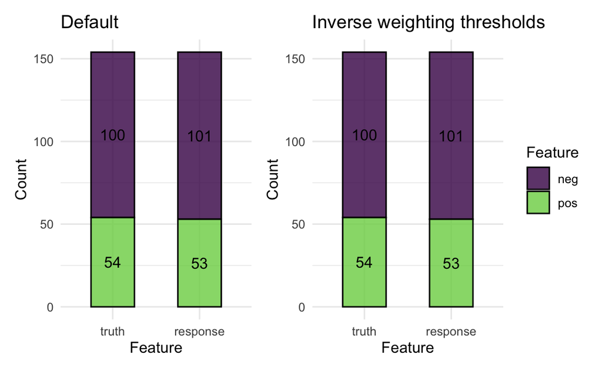

```r
prediction_plot_newt <- autoplot(prediction_rpart) +
                                ggtitle("Inverse weighting thresholds")
prediction_plot + prediction_plot_newt +
        plot_layout(guides = "collect")
```

Oh, it doesn’t make a difference!

##### Reducing false positive rate

This can be achieved by making it more difficult for the model to predict a positive result.

So, let’s create thresholds where the `pos` result is penalised.

```r
new_thresh <- c("pos" = 0.7, "neg" = 0.3)
```

```r
prediction_rpart$set_threshold(new_thresh)
prediction_rpart$confusion
```

```
        truth
response pos neg
     pos  35  10
     neg  19  90
```

```r
measures <- msrs(c("classif.tpr", "classif.fpr", "classif.tnr", "classif.fnr"))
prediction_rpart$score(measures)
```

```
classif.tpr classif.fpr classif.tnr classif.fnr
  0.6481481   0.1000000   0.9000000   0.3518519
```

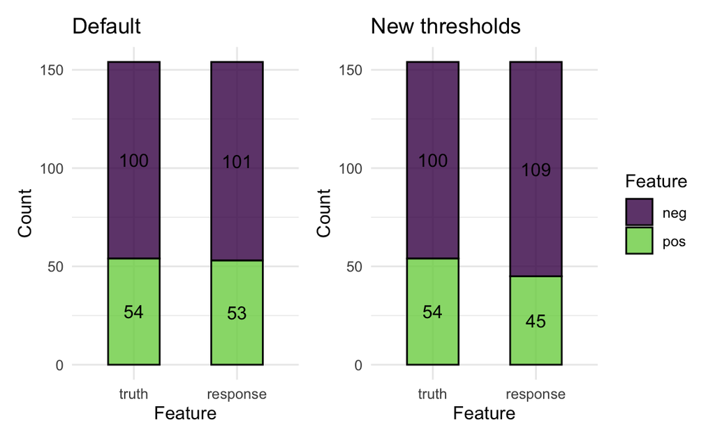

```r
prediction_plot_newt <- autoplot(prediction_rpart) +
                                ggtitle("New thresholds")
prediction_plot + prediction_plot_newt +
        plot_layout(guides = "collect")
```

Here, the false positive rate has decreased, but the false negative has increased (as expected).